# Bootstrapping and Cross Validation

Author

Dr. Niloufar Abourashchi and Dr. Thomas Honnor

# Introduction

## Population and samples

We are interested in drawing inferences about a population. For example, what is the mean height of a UCL Summer School student.

It is almost certainly the case that we cannot access the data for the entire population. The population of “UCL Summer School students” extends to those students who completed the summer school last year and those students who will complete it next year. We cannot collect their data now.

Instead, we have access to a sample of data from the population. I have access to the students completing ISSU0053 this year, so I could conceivably measure the heights of those students, constructing a sample from the broader population.

Assuming that our sample is representative of the population (for example, that ISSU0053 students this year are not consistently taller/shorter than those of the population, ideally achieved by taking a random sample from the population), quantities calculated for the sample should be “close to” the corresponding quantities for the population. For example, the mean height of ISSU0053 students this year should be “close to” the mean height of the population of UCL Summer School students.

Why do we only expect our sample result to be “close to” the population result? Why do we not expect the sample result to be exactly equal to the population result? The answer is the presence of inherent variability – student’s heights are not all identical, but instead vary around some mean value.

The result of this is that different samples will lead to different estimates of the mean. The mean height of students completing ISSU0053 in Session One will be different to the mean height of students completing ISSU0053 in Session Two. It is only by understanding this variability that we will be able to quantify the “close to” caveat above. We may then present the uncertainty arising from the variability through something like a confidence interval.

## The problem

In a number of cases there exists statistical theory by which uncertainty can be quantified through standard formulae and confidence intervals created analytically. Such cases are identified through the specification of assumptions. For example, that the population is normally distributed and/or that the sample is made up of observations sampled independently from the population.

In the grand scheme of all possible populations and all possible sampling methods, there exists far more cases where such standard assumptions are not satisfied than when they are. It would be very helpful to be able to quantify uncertainty in estimates, produce things like confidence intervals, etc. in such scenarios.

The ability of computers to perform billions of calculations in an instant means we can alternatively use resampling methods for estimating uncertainty, via the method of boostrap analysis. Bootstrap methodologies allow us to draw conclusions in a much wider range of cases, including those for which standard assumptions are not satisfied.

# The Bootstrap

## `for` loops in R

We first look at how to write a `for` loop in R, as the foundation for an approach which wants to perform similar calculations over and over again.

`for` loops allow us to run some commands a repeated number of times.

We saw one approach to this, via the `replicate` command, earlier in the course. A `for` loop is a more general approach to the same idea.

The following loop runs repeatedly with `i` taking the specified values of $1, 2, 3, 4, 5$.

```r
for (i in 1:5){
  print(i)
}
```

```
[1] 1
[1] 2
[1] 3
[1] 4
[1] 5
```

We can add code in the loop. For example, in this case we sum all the numbers from $1$ to $5$.

```r
sum_i <- 0

for (i in 1:5){
  sum_i <- sum_i + i
  print(sum_i)
}
```

```
[1] 1
[1] 3
[1] 6
[1] 10
[1] 15
```

**Note**

Why do we use the braces, `{` and `}`, in this code?

```r
for (i in 1:5) print(i)
```

```
[1] 1
[1] 2
[1] 3
[1] 4
[1] 5
```

```r
for (i in 1:5){
  print(i)
}
```

```
[1] 1
[1] 2
[1] 3
[1] 4
[1] 5
```

In this instance, it is possible to write all of the code in a single line, without the use of braces.

```r
sum_i <- 0
for (i in 1:5) sum_i <- sum_i+i; print(sum_i)
```

```
[1] 15
```

```r
sum_i <- 0
for (i in 1:5){sum_i <- sum_i+i; print(sum_i)}
```

```
[1] 1
[1] 3
[1] 6
[1] 10
[1] 15
```

```r
sum_i <- 0
for (i in 1:5){
  sum_i <- sum_i+i
  print(sum_i)
}
```

```
[1] 1
[1] 3
[1] 6
[1] 10
[1] 15
```

In this instance, the semicolon indicates to R that the proceeding code should be run and finished before the following code is run.

Braces connect code together, ensuring that both expressions are run at each stage of the loop, as opposed to the loop running through the first expression at each stage and then when all stages are complete running the second expression.

It is likely that someone (potentially only you, but it is good to be kind to your future self!) will read your code and need to make sense of it. Splitting the contents of a `for` loop onto multiple lines within braces is one method to make your code much more readable.

## Using a `for` loop to run repeated samplings

The principle of bootstrap analysis is that each time we draw a sample from a population, we are able to use that single sample to estimate the properties of the overall population.

For example, we draw $20$ values from a normal distribution with mean $120$ and standard deviation $10$:

```r
set.seed(111)

sim_data <- rnorm(n = 20, mean = 120, sd = 10)
```

**Note**

Why do we run the `set.seed` command here?

Computers ([generally](https://en.wikipedia.org/wiki/Lavarand)) generate randomness through algorithms. The starting points of those algorithms are known as “seeds”.

There may be cases where we want to obtain a reproducible set of random numbers, in which case we can set the seed for the random number generator first.

```r
set.seed(111)
sim_data <- rnorm(n = 20, mean = 120, sd = 10)
print(sim_data)
```

```
 [1] 122.35221 116.69264 116.88376  96.97654 118.29124 121.40278 105.02573
 [8] 109.89812 110.51524 115.06038 118.26326 115.93401 138.45636 123.94054
[15] 127.97529 104.33335 119.14149 116.40861 108.06391 123.64187
```

```r
sim_data <- rnorm(n = 20, mean = 120, sd = 10)
print(sim_data)
```

```
 [1] 123.61662 123.46964 121.89737 118.40423 123.26549 125.98254 101.58466
 [8] 147.18056 121.91244 106.98704  88.86783 110.58643 134.00259 103.79530
[15]  97.34004 131.62994 118.83845 123.34256 113.79142 106.90155
```

```r
set.seed(112)
sim_data <- rnorm(n = 20, mean = 120, sd = 10)
print(sim_data)
```

```
 [1] 116.8577 144.0338 112.8174 102.3939 108.7472 112.8046 133.1022 124.5190
 [9] 121.5218 126.5337 110.5266 109.2891 118.2394 138.7205 114.8966 134.3889
[17] 131.5317 118.4516 117.4009 124.7137
```

```r
set.seed(111)
sim_data <- rnorm(n = 20, mean = 120, sd = 10)
print(sim_data)
```

```
 [1] 122.35221 116.69264 116.88376  96.97654 118.29124 121.40278 105.02573
 [8] 109.89812 110.51524 115.06038 118.26326 115.93401 138.45636 123.94054
[15] 127.97529 104.33335 119.14149 116.40861 108.06391 123.64187
```

In a practical, real-world scenario, we would use the sample values to infer information on the population. For example, to estimate the population mean, $\mu$, we calculate the sample mean, $\bar{x}$:

```r
mean(sim_data)
```

```
[1] 116.4629
```

This sample mean provides us with a value which is close to (but not exactly equal to) the population mean, which we previously specified to be equal to $120$.

For a sample of $n$ independent observations taken from a population with standard deviation $\sigma$, analytical results give that the standard deviation of the calculated sample mean is $\sigma/\sqrt{n}$.

In the same way that we don’t know the population mean, $\mu$, and we therefore estimate it using the sample mean, $\bar{x}$, we also don’t know the population standard deviation, $\sigma$, and we therefore estimate it using the sample standard deviation, $s$.

An estimate of the standard error of the sample mean is therefore:

```r
n <- length(sim_data)

standard_error_sample <- sd(sim_data)/sqrt(n)
standard_error_sample
```

```
[1] 2.055603
```

```r
standard_error_population <- 10/sqrt(20)
standard_error_population
```

```
[1] 2.236068
```

This gives us the spread (standard deviation) of the distribution of the estimate around the true value.

We can use this estimate of the error to produce a 95% confidence interval for the true population mean as sample mean $\pm 2$ standard errors, $\bar{x}\pm 2\times s/\sqrt{n}$.

The $\pm 2$ standard errors comes from the fact that our sample mean is normally distributed (via the Central Limit Theorem), and for a normal distribution 95% of the distribution lies within approximately 2 standard deviations of the mean.

```r
estimate_m <- mean(sim_data)
estimate_m
```

```
[1] 116.4629
```

```r
upper_limit <- estimate_m + 2*standard_error_sample
upper_limit
```

```
[1] 120.5741
```

```r
lower_limit <- estimate_m - 2*standard_error_sample
lower_limit
```

```
[1] 112.3517
```

To summarise this first discussion:

- We are interested in an estimate of the population mean, $\mu$.
- A point estimate of the population mean can be trivially produced using a single sample, by calculating the sample mean, $\bar{x}$.
- What confidence can we put in that estimate? It would be very useful to be able to quantify the uncertainty in that estimate.
- If we claim to know that our population is normally distributed (and/or if our sample size is large enough for the Central Limit Theorem to apply), our sample mean is normally distributed.
  - This result only holds true because we are interested in a mean.
- We can then make use of the well-known fact that a normal distribution contains 95% of its probability within $\pm 2$ standard errors of the mean, to construct a 95% confidence interval for our mean estimate.
  - As we are working with the sample mean, the corresponding standard error is $\sigma/\sqrt{n}$, which we are forced to estimate as $s/\sqrt{n}$.
  - This result, for the standard error of the mean, does not rely upon the fact that our population is normally distributed. However, it is specific to the fact that this is the standard error of the mean.

An alternative way to estimate the uncertainty in the mean estimate would be to repeatedly sample the population and look at the resulting distribution of the sample mean estimates.

We can use R and for loops to do this.

Here we run an experiment where we draw $100$ samples, each of $20$ data points, and calculate the mean. To store the values we first create an empty vector `sample_means` with $100$ entries, which we fill as we go through the loop:

```r
sample_means <- rep(0, 100)

for (i in 1:100){
  sim_data <- rnorm(n = 20, mean = 120, sd = 10)
  sample_means[i] <- mean(sim_data)
}
```

We can look at the resulting distribution of the sample means:

```r
library(tidyverse)
```

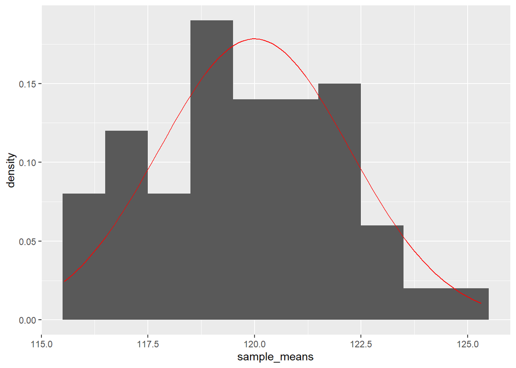

```r
ggplot() +
  geom_histogram(aes(x=sample_means,y=after_stat(density)),binwidth=1) +
  stat_function(fun = dnorm,args = list(mean=120,sd=10/sqrt(20)),colour="red")
```

In this case the width (standard deviation) of the distribution corresponds to the standard error, and we can check this by comparison with the above calculations:

```r
sd(sample_means)
```

```
[1] 2.240519
```

```r
standard_error_population
```

```
[1] 2.236068
```

A 95% confidence interval for the population mean estimate can be crudely approximated by taking the interval containing the central 95% of the population mean estimates. That is, from the 2.5th to the 97.5th quartile of this collection of sample means.

```r
quantile(sample_means, c(0.025,0.975))
```

```
   2.5%   97.5%
115.645 123.806
```

```r
lower_limit
```

```
[1] 112.3517
```

```r
upper_limit
```

```
[1] 120.5741
```

Here we have shown that a “brute force” method of repeated sampling is able to also provide estimates for errors. However, in the real world we are unable to repeated draw new samples (if it was that easy to collect samples, we would simply collect more data in the first place!).

**Note**

What do you expect to happen as greater numbers of samples?

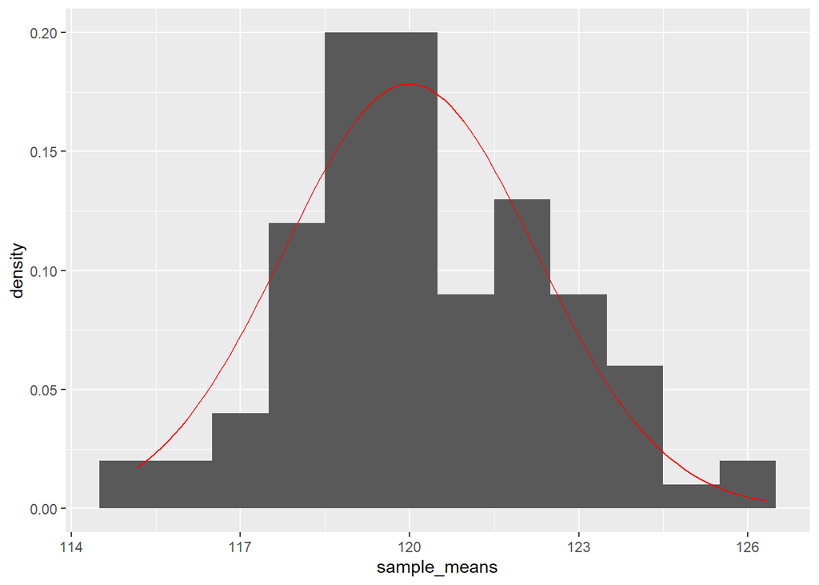

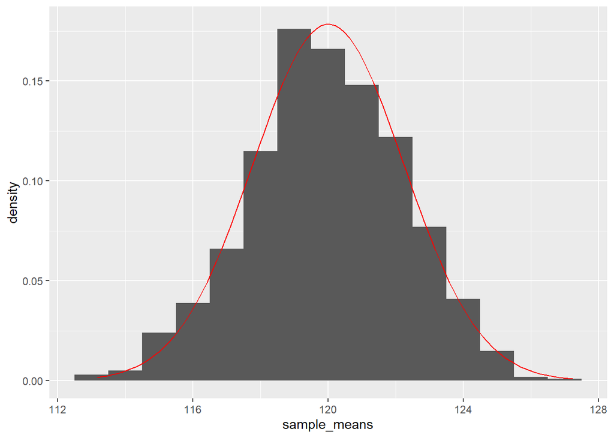

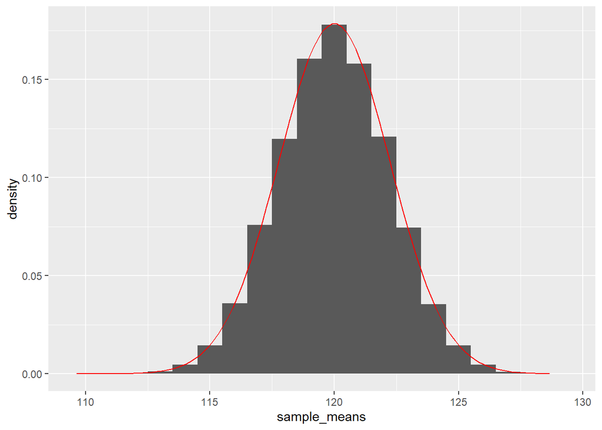

```r
m <- c(100,1000,10000)

for (j in 1:3){

  sample_means <- rep(0,m[j])

  for (i in 1:m[j]){
    sim_data <- rnorm(n = 20, mean = 120, sd = 10)
    sample_means[i] <- mean(sim_data)
  }

  print(ggplot() +
          geom_histogram(aes(x=sample_means,y=after_stat(density)),binwidth=1) +
          stat_function(fun = dnorm, args = list(mean = 120, sd = 10/sqrt(20)), colour = "red"))

}
```

## Resampling datasets

If we are estimating other distributional quantities, or we are again estimating the mean using a small sample from a non-normal distribution (in which case the Central Limit Theorem does not apply), the previous theoretical results for calculating a confidence interval (estimate $\pm 2$ standard errors) no longer applies. We need another technique in order to make progress.

This is where boostrapping comes in. Bootstrapping means resampling from our dataset randomly to generate “new” datasets. Compare/contrast this with the final parts of our previous discussion, where we were resampling from the population.

The code below takes a vector with 20 entries and repeatedly selects a random entry from this dataset 20 times, with replacement, to generate a so-called resampled, bootstrapped dataset:

```r
set.seed(111)
sim_data <- rnorm(n = 20, mean = 120, sd = 10)

bootstrapped_data <- sample(sim_data, size = 20, replace = T)
```

The `replace = T` argument tells R that after sampling an entry, it is replaced so that it can be selected again. This means some elements in the original sample are selected multiple times, and some are not selected at all. Our “new” sample must be the same size as the original sample (we saw in the previous theoretical discussion that the standard error is directly linked to the sample size, $n$, so we want to keep this consistent and fixed). Resampling without replacement, to produce a sample the same size as the original sample, would simply lead us to generating the original sample over and over again – clearly not useful.

We can see that some sample observations appear multiple times in the bootstrapped sample via a frequency table:

```r
table(bootstrapped_data)
```

```
bootstrapped_data
96.9765434157062 104.333346398144 105.025733444349 110.515243950476
               3                1                1                1
115.060377827649 116.408605187622 118.291239553861 119.141489911774
               3                1                2                1
121.402782251032 122.352207116137 123.641867370222 138.456362638071
               3                1                2                1
```

Below we draw a dot plot to compare the original sample and the bootstrap resample:

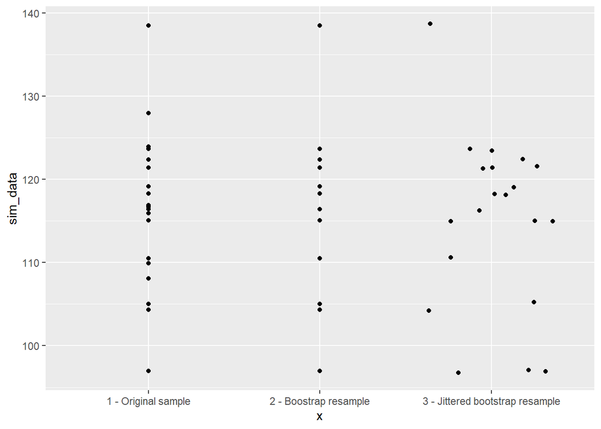

```r
ggplot() +
  geom_point(mapping=aes(y=sim_data, x="1 - Original sample")) +
  geom_point(mapping=aes(y=bootstrapped_data, x="2 - Boostrap resample")) +
  geom_jitter(mapping=aes(y=bootstrapped_data, x="3 - Jittered bootstrap resample"))
```

Because the boostrap resample entries are randomly selected from the sample it has a different mean:

```r
mean(sim_data)
```

```
[1] 116.4629
```

```r
mean(bootstrapped_data)
```

```
[1] 115.0209
```

In this way we have used resampling to artificially create a “new” sample, with a “new” mean estimate.

We can repeat the resampling many times to construct a distribution of results:

```r
sim_data <- rnorm(n = 20, mean = 120, sd = 10)

bootstrapped_means <- rep(0, 100)

for (i in 1:100){
  bootstrapped_data <- sample(sim_data, size = 20, replace = T)
  bootstrapped_means[i] <- mean(bootstrapped_data)
}
```

We can view the distribution of the calculated mean values:

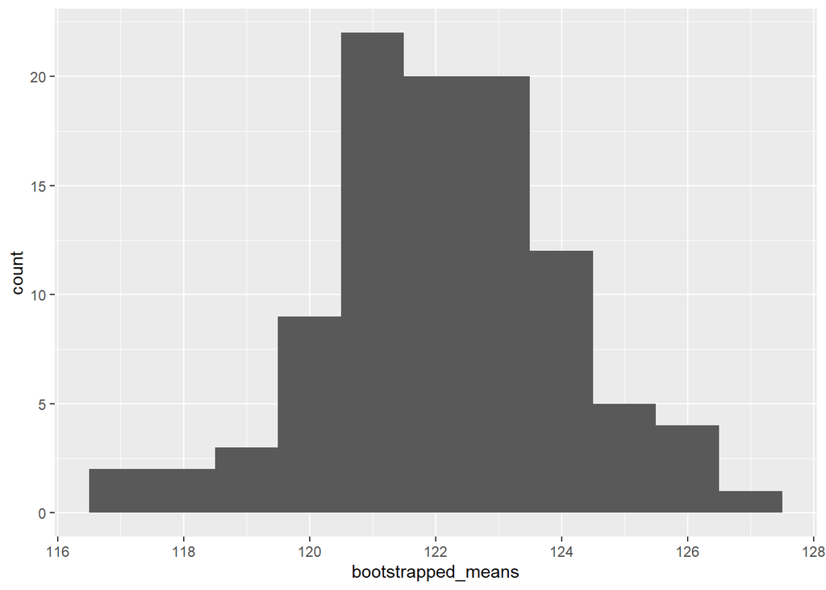

```r
ggplot() +
  geom_histogram(mapping=aes(x=bootstrapped_means), binwidth=1)
```

We can also measure its width, to estimate the error:

```r
sd(bootstrapped_means)
```

```
[1] 1.906206
```

We see that in this case the estimate is in rough agreement with the level of error predicted by the other methods. In general, when we bootstrap a dataset we take enough bootstrap samples such that we can make a reasonable estimate for the standard deviation of the distribution of the boostrapped measurements (typically at least $30$, but higher, e.g. $>100$, if we want to look at the 95% confidence interval).

This method can be applied to data from any population distribution, and to estimates of any property of the distribution (not just the mean).

Below, we show that for a large dataset where the assumption of a normally distributed population holds the two methods give results that are in agreement:

```r
sim_data <- rnorm(n = 2000, mean = 120, sd = 10)
n <- length(sim_data)

n_repeats <- 1000
bootrapped_means <- rep(0, n_repeats)

for (i in 1:n_repeats){
  bootstrapped_data <- sample(sim_data, size = 2000, replace = T)
  bootrapped_means[i] <- mean(bootstrapped_data)
}

boostrap_se <- sd(bootrapped_means)
boostrap_se
```

```
[1] 0.2248687
```

```r
# from standard error method
stats_se <- sd(sim_data)/sqrt(n)
stats_se
```

```
[1] 0.2244854
```

## Applying the bootstrap method to quantify the uncertainty in model coefficients

We can apply the bootstrap method to any analysis. Here we can use the boostrap analysis to measure the uncertainty in fit coefficients of the high school analysis.

First we set up the dataset.

```r
library(tidyverse)

select <- dplyr::select

female_labels <- c("male","female")
race_labels <- c("hispanic", "asian", "african-american", "white")
ses_labels <- c("low", "middle", "high")
schtyp_labels <- c("public","private")
prog_labels <- c("general", "academic", "vocational")

highschool <- read_csv("hsb2.csv", col_types = "dfffffddddd") %>%
  mutate(gender = factor(female, levels = c(0,1),labels = female_labels),
         race = factor(race, levels = c(1,2,3,4), labels = race_labels),
         ses = factor(ses, levels = c(1,2,3),labels = ses_labels),
         schtyp = factor(schtyp, levels = c(1,2), labels = schtyp_labels),
         prog = factor(prog, levels = c(1,2,3), labels = prog_labels)
         ) %>%
  select(-female)
glimpse(highschool)
```

```
Rows: 200
Columns: 11
$ id      <dbl> 70, 121, 86, 141, 172, 113, 50, 11, 84, 48, 75, 60, 95, 104, 3…
$ race    <fct> white, white, white, white, white, white, african-american, hi…
$ ses     <fct> low, middle, high, high, middle, middle, middle, middle, middl…
$ schtyp  <fct> public, public, public, public, public, public, public, public…
$ prog    <fct> general, vocational, general, vocational, academic, academic, …
$ read    <dbl> 57, 68, 44, 63, 47, 44, 50, 34, 63, 57, 60, 57, 73, 54, 45, 42…
$ write   <dbl> 52, 59, 33, 44, 52, 52, 59, 46, 57, 55, 46, 65, 60, 63, 57, 49…
$ math    <dbl> 41, 53, 54, 47, 57, 51, 42, 45, 54, 52, 51, 51, 71, 57, 50, 43…
$ science <dbl> 47, 63, 58, 53, 53, 63, 53, 39, 58, 50, 53, 63, 61, 55, 31, 50…
$ socst   <dbl> 57, 61, 31, 56, 61, 61, 61, 36, 51, 51, 61, 61, 71, 46, 56, 56…
$ gender  <fct> male, female, male, male, male, male, male, male, male, male, …
```

Now we show the model we are going to test:

```r
lm_simple <- lm(read ~ write + prog, data=highschool)

summary(lm_simple)
```

```
Call:
lm(formula = read ~ write + prog, data = highschool)

Residuals:
     Min       1Q   Median       3Q      Max
-18.8066  -5.6785  -0.1367   5.0873  22.1920

Coefficients:
               Estimate Std. Error t value Pr(>|t|)
(Intercept)     21.3723     3.6139   5.914 1.46e-08 ***
write            0.5529     0.0664   8.327 1.41e-14 ***
progacademic     3.6839     1.4714   2.504   0.0131 *
progvocational  -1.0269     1.6822  -0.610   0.5423
---
Signif. codes:  0 '***' 0.001 '**' 0.01 '*' 0.05 '.' 0.1 ' ' 1

Residual standard error: 8.052 on 196 degrees of freedom
Multiple R-squared:  0.3926,    Adjusted R-squared:  0.3833
F-statistic: 42.22 on 3 and 196 DF,  p-value: < 2.2e-16
```

To see what we can extract from the summary object use the `str` function. This shows the attributes we can access with the $ notation.

```r
str( summary(lm_simple) )
```

```
List of 11
 $ call         : language lm(formula = read ~ write + prog, data = highschool)
 $ terms        :Classes 'terms', 'formula'  language read ~ write + prog
  .. ..- attr(*, "variables")= language list(read, write, prog)
  .. ..- attr(*, "factors")= int [1:3, 1:2] 0 1 0 0 0 1
  .. .. ..- attr(*, "dimnames")=List of 2
  .. .. .. ..$ : chr [1:3] "read" "write" "prog"
  .. .. .. ..$ : chr [1:2] "write" "prog"
  .. ..- attr(*, "term.labels")= chr [1:2] "write" "prog"
  .. ..- attr(*, "order")= int [1:2] 1 1
  .. ..- attr(*, "intercept")= int 1
  .. ..- attr(*, "response")= int 1
  .. ..- attr(*, ".Environment")=<environment: R_GlobalEnv>
  .. ..- attr(*, "predvars")= language list(read, write, prog)
  .. ..- attr(*, "dataClasses")= Named chr [1:3] "numeric" "numeric" "factor"
  .. .. ..- attr(*, "names")= chr [1:3] "read" "write" "prog"
 $ residuals    : Named num [1:200] 6.88 15.03 4.38 18.33 -6.81 ...
  ..- attr(*, "names")= chr [1:200] "1" "2" "3" "4" ...
 $ coefficients : num [1:4, 1:4] 21.372 0.553 3.684 -1.027 3.614 ...
  ..- attr(*, "dimnames")=List of 2
  .. ..$ : chr [1:4] "(Intercept)" "write" "progacademic" "progvocational"
  .. ..$ : chr [1:4] "Estimate" "Std. Error" "t value" "Pr(>|t|)"
 $ aliased      : Named logi [1:4] FALSE FALSE FALSE FALSE
  ..- attr(*, "names")= chr [1:4] "(Intercept)" "write" "progacademic" "progvocational"
 $ sigma        : num 8.05
 $ df           : int [1:3] 4 196 4
 $ r.squared    : num 0.393
 $ adj.r.squared: num 0.383
 $ fstatistic   : Named num [1:3] 42.2 3 196
  ..- attr(*, "names")= chr [1:3] "value" "numdf" "dendf"
 $ cov.unscaled : num [1:4, 1:4] 0.20144 -0.00349 -0.00503 -0.03819 -0.00349 ...
  ..- attr(*, "dimnames")=List of 2
  .. ..$ : chr [1:4] "(Intercept)" "write" "progacademic" "progvocational"
  .. ..$ : chr [1:4] "(Intercept)" "write" "progacademic" "progvocational"
 - attr(*, "class")= chr "summary.lm"
```

In this case the fit coefficients can be accessed from the fit summary using `$coefficients[]`.

```r
B1 <- summary(lm_simple)$coefficients[2,1] # write coefficient
B2 <- summary(lm_simple)$coefficients[3,1] # progacademic coefficient
B3 <- summary(lm_simple)$coefficients[4,1] # progvocational coefficient
```

To use the bootstrap method to explore how the coefficients change when the dataset is resampled, we follow the method from above, but this time select rows from the original dataset at random, with the `sample_n` function:

```r
n_repeats <- 100

B1_vals <- rep(0, n_repeats)
B2_vals <- rep(0, n_repeats)
B3_vals <- rep(0, n_repeats)

n <- nrow(highschool)

for (i in 1:n_repeats){
  highschool_bstrap <- sample_n(highschool, size = 200, replace=T )
  lm_simple <- lm(read ~ write + prog, data=highschool_bstrap)

  B1 <- summary(lm_simple)$coefficients[2,1]
  B2 <- summary(lm_simple)$coefficients[3,1]
  B3 <- summary(lm_simple)$coefficients[4,1]

  B1_vals[i] <- B1
  B2_vals[i] <- B2
  B3_vals[i] <- B3
}

B1_sd <- sd(B1_vals)
B2_sd <- sd(B2_vals)
B3_sd <- sd(B3_vals)
```

```r
paste("coef: bootstrap SD : lm fit estimate SE")
```

```
[1] "coef: bootstrap SD : lm fit estimate SE"
```

```r
paste( "B1:  ",round(sd(B1_vals),3),"       :",round(summary(lm_simple)$coefficients[2,2],3))
```

```
[1] "B1:   0.057        : 0.073"
```

```r
paste( "B2:  ",round(sd(B2_vals),3),"       :",round(summary(lm_simple)$coefficients[3,2],3))
```

```
[1] "B2:   1.445        : 1.527"
```

```r
paste( "B3:  ",round(sd(B3_vals),3),"       :",round(summary(lm_simple)$coefficients[4,2],3))
```

```
[1] "B3:   1.744        : 1.963"
```

If the assumptions required for the t-test results displayed in the linear regression output to be valid are not satisfied, a bootstrap procedure like the one outlined above could be used to test whether a given coefficient value is significantly different from zero.

- Produce an estimate of the coefficient value by fitting the model to the original sample.
- Build up the distribution of the estimate via a bootstrapping procedure.
- Report the limits of a 95% confidence interval by obtaining the relevant quantiles of the bootstrap distribution of coefficient estimates.
- Reject the null hypothesis if zero lies outside of this confidence interval.

A general principle is that the greater the amount of information available, the more accurate the results. For example, larger sample sizes contain more information and therefore may provide more accurate estimates.

This principle can be carried forwards to a decision of whether to use the bootstrap or to use parametric methods. If the necessary assumptions for a parametric method to be valid are satisfied, applying the parametric method will retain more information than using a bootstrap technique (which does not care whether those assumptions are satisfied), and therefore generally lead to more accurate results. If the necessary assumptions for a parametric method to be valid are not satisfied, it makes little sense to apply the parametric method and we might choose to apply a bootstrap alternative instead.

As with most of the techniques taught as part of this course, there is considerably greater depth and breadth to bootstrap techniques than we are able to introduce here.

# Cross Validation

When we try to estimate performance of a model, a key problem is that the model may have overfitted the training data. In this case we find the model fits the “noise” in addition to the “pattern” between the input and output variables. A result of this is that the performance (size of residuals) measured on the training data will be very low, but the performance on new data will be poorer.

When we look at model performance we need to avoid overestimating performance due to overfitting of training data. Cross Validation, or CV, is the standard method to do this.

The code below shows how to perform k-fold cross validation. To illustrate we first build two model: `lm_full` with the full set of possible predictors, then compare this to the optimal model `lm_opt` found previously by exhaustive search using the `leaps` package, which included `science`, `read`, `write` and `prog` only.

```r
lm_full <- lm(math ~ ., data=highschool)

lm_opt <- lm(math ~ science + write + read + prog, data=highschool)
```

We can manually calculate the RMSE (root mean squared error) using the sum of the squared residuals:

```r
# RMSE for fit to training data
fitted_math <- predict(lm_full)
mse <- sum((fitted_math - highschool$math)^2)/nrow(highschool)
rmse <- sqrt(mse)
rmse
```

```
[1] 5.855575
```

```r
fitted_math_opt <- predict(lm_opt)
mse_opt <- sum((fitted_math_opt- highschool$math)^2)/nrow(highschool)
rmse_opt <- sqrt(mse_opt)
rmse_opt
```

```
[1] 5.987636
```

We see that the full model has smaller residuals when making predictions for the data we used to train the fit. This is expected, as the full model has more flexibility, so can be optimised to better fit the training data.

However, to test the expected performance on new data not used in the fit (and prevent overfitting from overestimating performance) we look at the cross validated performance:

```r
library(cvTools)
```

```r
# cvFit gives RMSE value
cvFit(lm_full, data=highschool, y=highschool$math, K=5, R = 1)
```

```
5-fold CV results:
      CV
6.344695
```

```r
# cvFit gives RMSE value
cvFit(lm_opt, data=highschool, y=highschool$math, K=5, R = 1)
```

```
5-fold CV results:
      CV
6.206877
```

In this case we find that the smaller model `lm_opt` has better performance as measured by cross validation, indicating that the better performance of the full model on training data was due to overfitting, rather than a better estimate for the “true” relationship between input and output variables.

## Adding repeats to estimate an error range on the CV performance

We can make the function run a number of repeats, each time splitting the data differently into k-folds. We can then look at the range of performance estimates from each repeat, to get an idea of the error in our performance estimate.

```r
cv_result <- cvFit(lm_full, data=highschool, y=highschool$math, K=5, R = 20)

cv_result$cv # contains the cross validation performance measure
```

```
      CV
6.424719
```

```r
cv_result$se # contains measured error in estimate based on repeats
```

```
       CV
0.1282177
```

```r
cv_result_opt <- cvFit(lm_opt, data=highschool, y=highschool$math, K=5, R = 20)

cv_result_opt$cv # contains the cross validation performance measure
```

```
      CV
6.207977
```

```r
cv_result_opt$se # contains measured error in estimate based on repeats
```

```
        CV
0.05705681
```

This measure of error can help when we come to compare values between methods, i.e. performance estimates are: $6.21\pm 0.06$ for the optimised model and $6.42\pm 0.13$ for the full model.